# 01 xts time series examples

John Yuill

2021-01-08

## Purpose

Provide some basic examples of using ‘xts’ (extensible time series) which is a powerful way to work with time-related data in R.

For more details and examples:

- [xts cheat sheet](https://www.datacamp.com/community/blog/r-xts-cheat-sheet)

## Get some data

- import financial stock data using quantmod pkg, which automatically imports data as ‘xts’ object

```r
getSymbols(Symbols='CSIQ', auto.assign=TRUE)
```

```
## [1] "CSIQ"
```

```r
str(CSIQ)
```

```
## An 'xts' object on 2007-01-03/2021-01-07 containing:
##   Data: num [1:3529, 1:6] 11 10.8 10.5 10.1 10 ...
##  - attr(*, "dimnames")=List of 2
##   ..$ : NULL
##   ..$ : chr [1:6] "CSIQ.Open" "CSIQ.High" "CSIQ.Low" "CSIQ.Close" ...
##   Indexed by objects of class: [Date] TZ: UTC
##   xts Attributes:
## List of 2
##  $ src    : chr "yahoo"
##  $ updated: POSIXct[1:1], format: "2021-01-08 13:47:29"
```

```r
head(CSIQ)
```

```
##            CSIQ.Open CSIQ.High CSIQ.Low CSIQ.Close CSIQ.Volume
## 2007-01-03     10.98     11.00    10.65      10.82      176300
## 2007-01-04     10.82     10.82    10.39      10.41      164100
## 2007-01-05     10.50     10.70    10.12      10.15       68600
## 2007-01-08     10.10     10.34     9.95       9.98      195500
## 2007-01-09     10.00     10.05     9.77       9.77       85900
## 2007-01-10      9.69      9.97     9.61       9.68       77800
##            CSIQ.Adjusted
## 2007-01-03         10.82
## 2007-01-04         10.41
## 2007-01-05         10.15
## 2007-01-08          9.98
## 2007-01-09          9.77
## 2007-01-10          9.68
```

```r
## drop Adjusted col moving fwd to save space when printing
CSIQ <- CSIQ[,1:5]
```

## Basic filtering/subsetting

### Filter dates

- after given date

```r
CSIQ_2020 <- CSIQ['2020-01-01/'] ## from specified date fwd
head(CSIQ_2020)
```

```
##            CSIQ.Open CSIQ.High CSIQ.Low CSIQ.Close CSIQ.Volume
## 2020-01-02     22.36     22.54    22.04      22.52      643300
## 2020-01-03     22.19     22.44    21.59      21.80      809600
## 2020-01-06     21.31     22.33    21.10      22.32      938000
## 2020-01-07     22.29     22.60    22.22      22.36      596900
## 2020-01-08     22.37     22.71    22.11      22.57      709800
## 2020-01-09     22.61     23.38    22.61      22.89      788800
```

- before given end date

```r
CSIQ_2019 <- CSIQ['/2020-01-01'] ## from specified date fwd
tail(CSIQ_2019)
```

```
##            CSIQ.Open CSIQ.High CSIQ.Low CSIQ.Close CSIQ.Volume
## 2019-12-23     21.20     21.83    21.01      21.81      752000
## 2019-12-24     21.84     22.19    21.67      22.15      364100
## 2019-12-26     22.20     22.61    22.06      22.32      519300
## 2019-12-27     22.32     22.32    21.67      21.79      519000
## 2019-12-30     21.71     21.93    21.21      21.86      662000
## 2019-12-31     21.83     22.18    21.74      22.10      344800
```

- rolling recent period

```r
## last n items

CSIQ_7d <- tail(CSIQ, n=7)
CSIQ_7d
```

```
##            CSIQ.Open CSIQ.High CSIQ.Low CSIQ.Close CSIQ.Volume
## 2020-12-29     51.09     51.23    48.07      49.51     2069700
## 2020-12-30     50.28     52.25    49.88      50.68     1587700
## 2020-12-31     51.08     52.16    49.97      51.24     1408500
## 2021-01-04     52.54     54.14    51.83      52.64     1789200
## 2021-01-05     51.03     53.18    49.37      50.52     2388200
## 2021-01-06     53.90     56.88    53.13      54.31     4437000
## 2021-01-07     58.21     59.19    55.56      56.61     2850800
```

- specified period

```r
## selected period
CSIQ_Aug <- CSIQ['2020-08/2020-08-31'] ## Aug 1-31
CSIQ_Aug
```

```
##            CSIQ.Open CSIQ.High CSIQ.Low CSIQ.Close CSIQ.Volume
## 2020-08-03     22.21     22.47    22.04      22.42      827600
## 2020-08-04     22.63     24.29    22.57      23.98     1440900
## 2020-08-05     24.10     24.15    23.13      23.77      970100
## 2020-08-06     23.69     24.13    23.35      23.62     1019200
## 2020-08-07     25.00     26.72    24.62      25.32     4182300
## 2020-08-10     25.20     25.48    23.94      24.46     1791100
## 2020-08-11     24.54     24.72    23.32      24.04     1184500
## 2020-08-12     24.00     25.73    24.00      25.03     1806300
## 2020-08-13     25.07     26.55    24.60      26.38     2397900
## 2020-08-14     26.41     26.41    25.51      25.89     1518600
## 2020-08-17     26.08     26.48    25.63      25.94     1253300
## 2020-08-18     26.00     27.27    25.75      26.70     1999100
## 2020-08-19     26.78     27.28    26.36      26.59     1439200
## 2020-08-20     26.26     26.59    25.45      25.69     1224300
## 2020-08-21     25.59     26.65    25.59      25.96      940800
## 2020-08-24     26.14     27.63    26.06      27.06     1973600
## 2020-08-25     27.12     27.78    26.73      27.72     1488600
## 2020-08-26     28.00     28.83    27.80      28.05     2447600
## 2020-08-27     28.00     28.98    27.61      28.64     1614500
## 2020-08-28     29.25     32.72    28.92      32.52     4842400
## 2020-08-31     32.45     34.10    31.78      32.49     2033100
```

### Filter cols

- as in base R

```r
CSIQ_2020_cl <- CSIQ_2020[,4]
head(CSIQ_2020_cl)
```

```
##            CSIQ.Close
## 2020-01-02      22.52
## 2020-01-03      21.80
## 2020-01-06      22.32
## 2020-01-07      22.36
## 2020-01-08      22.57
## 2020-01-09      22.89
```

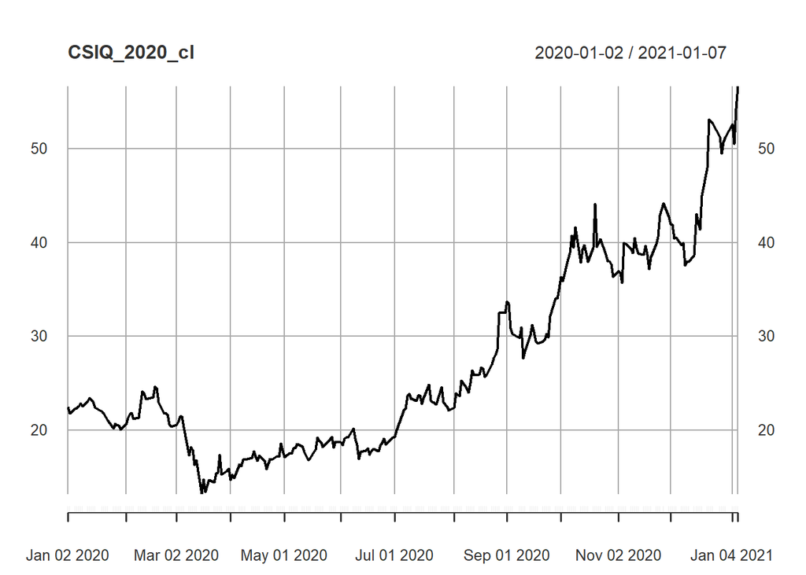

```r
plot(CSIQ_2020_cl) ## use basic R plot
```

## Visualize

- several options (where ‘x’ is your xts object) -> in order shown below
  - plot(x): basic R plotting, will recognize ts and format dates
  - ts.plot(x): specifically for time series, shows dates as index numbers
  - plot.xts(x): very similar to basic plot
  - dygraph(x): often used of financial charts; requires dygraphs pkg
  - chart.TimeSeries(x): from PerformanceAnalytics pkg

Very simple examples. The last 3 choices above have many additional options, especially for financial data.

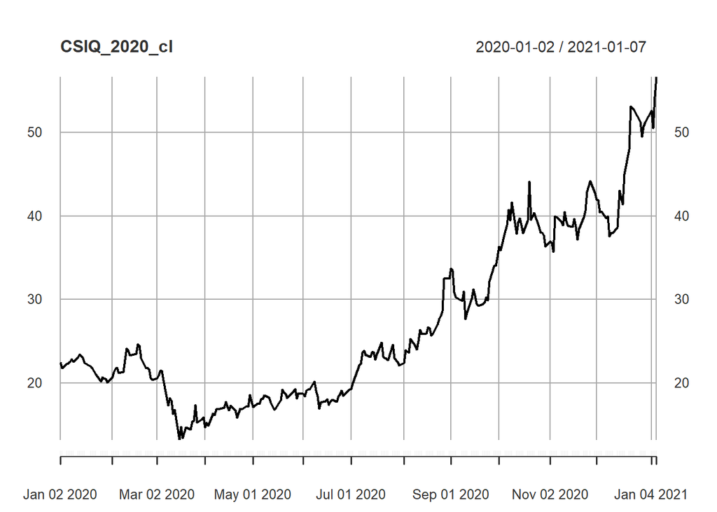

```r
plot(CSIQ_2020_cl)
```

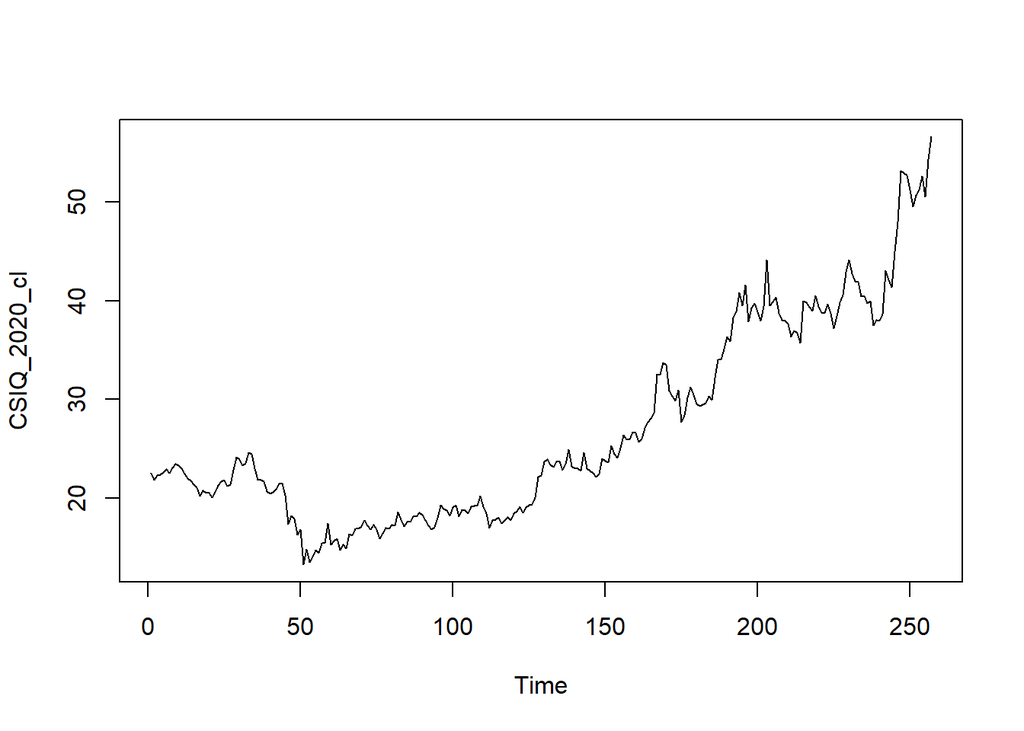

```r
ts.plot(CSIQ_2020_cl)
```

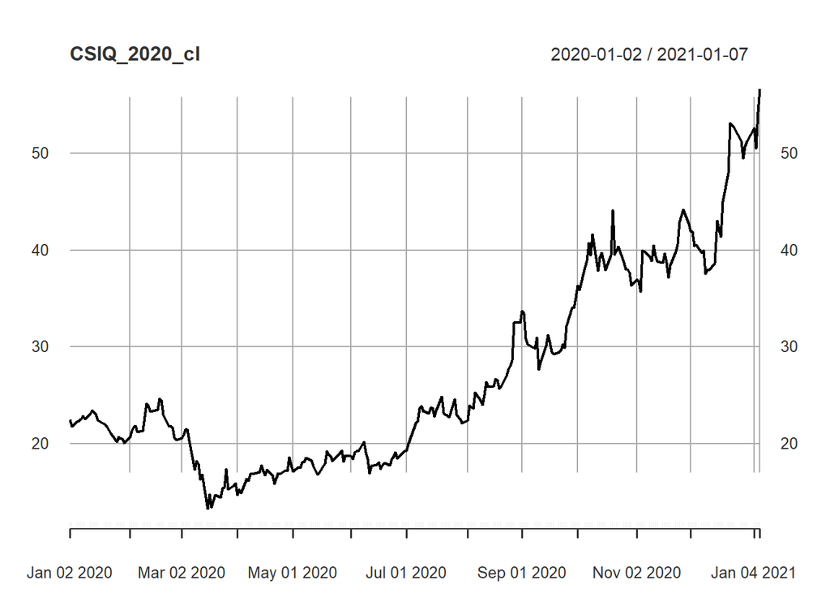

```r
plot.xts(CSIQ_2020_cl)
```

```r
dygraph(CSIQ_2020_cl)
```

[interactive chart not shown]

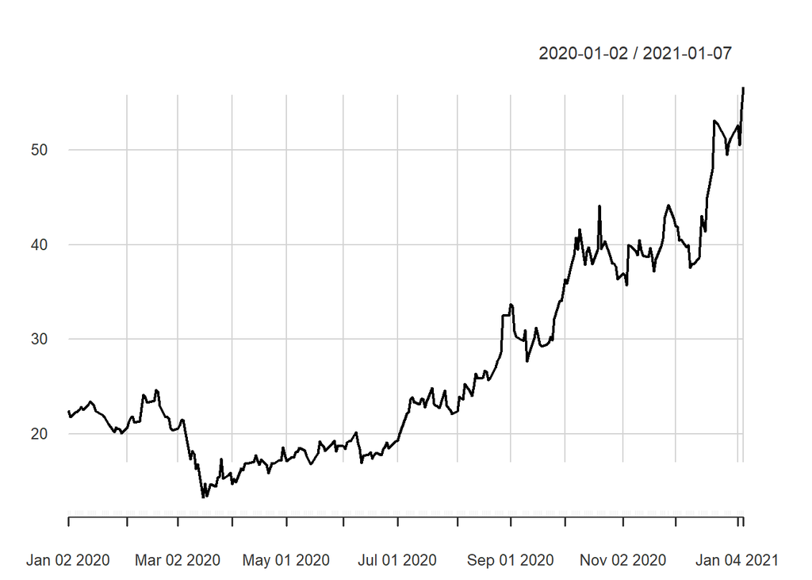

```r
chart.TimeSeries(CSIQ_2020_cl)
```

## Time Series Manipulation

Leverage xts to work with time series objects

### End points by period

- day, week, month, qtr, yr.
- returns the locations of each last item in the specified type of period, aligned on calendar.
- will include the last item available in the last period (last data point).
- returns a vector starting with 0 and ending with the extent (last row) of your data.
- can also use k to skip: on=‘years’, k=4 returns location of every 4th yr in data (plus last)

```r
## get index number of last day of each year
index_yr <- endpoints(CSIQ, on="years")
## apply to time series to extract selected end points
CSIQ_yr_end <- CSIQ[index_yr]
head(CSIQ_yr_end[,c(2,3,5)]) ## selected cols for space
```

```
##            CSIQ.High CSIQ.Low CSIQ.Volume
## 2007-12-31     29.15    27.26     1461900
## 2008-12-31      6.95     6.37     1024900
## 2009-12-31     29.44    28.81      686600
## 2010-12-31     12.41    12.12      510700
## 2011-12-30      2.70     2.53      350400
## 2012-12-31      3.43     3.25      506200
```

```r
dygraph(CSIQ_yr_end[,2])
```

[interactive chart not shown]

```r
index_week_end <- endpoints(CSIQ_Aug, on="weeks")
CSIQ_Aug[index_week_end, 1:4] ## open, high, low, close selected
```

```
##            CSIQ.Open CSIQ.High CSIQ.Low CSIQ.Close
## 2020-08-07     25.00     26.72    24.62      25.32
## 2020-08-14     26.41     26.41    25.51      25.89
## 2020-08-21     25.59     26.65    25.59      25.96
## 2020-08-28     29.25     32.72    28.92      32.52
## 2020-08-31     32.45     34.10    31.78      32.49
```

### Summarization

```r
##
period.apply(CSIQ_Aug, INDEX=index_week_end, FUN=mean)
```

```
##            CSIQ.Open CSIQ.High CSIQ.Low CSIQ.Close CSIQ.Volume
## 2020-08-07    23.526    24.352   23.142     23.822     1688020
## 2020-08-14    25.044    25.778   24.274     25.160     1739680
## 2020-08-21    26.142    26.854   25.756     26.176     1371340
## 2020-08-28    27.702    29.188   27.424     28.798     2473340
## 2020-08-31    32.450    34.100   31.780     32.490     2033100
```

### Shortcut summarization

```r
## apply.weekly, apply.monthly, apply.quarterly, apply.yearly to summarize
## FUN=<whatever summarization function for the period)
apply.weekly(CSIQ_Aug, FUN=mean)
```

```
##            CSIQ.Open CSIQ.High CSIQ.Low CSIQ.Close CSIQ.Volume
## 2020-08-07    23.526    24.352   23.142     23.822     1688020
## 2020-08-14    25.044    25.778   24.274     25.160     1739680
## 2020-08-21    26.142    26.854   25.756     26.176     1371340
## 2020-08-28    27.702    29.188   27.424     28.798     2473340
## 2020-08-31    32.450    34.100   31.780     32.490     2033100
```

### Split into periods

```r
## split data into weeks - chunk the data into 'week' components, without summarizing
CSIQ_Aug_weeks <- split(CSIQ_Aug, f='weeks')
## second week: high, low, close selected
CSIQ_Aug_weeks[[2]][,2:4]
```

```
##            CSIQ.High CSIQ.Low CSIQ.Close
## 2020-08-10     25.48    23.94      24.46
## 2020-08-11     24.72    23.32      24.04
## 2020-08-12     25.73    24.00      25.03
## 2020-08-13     26.55    24.60      26.38
## 2020-08-14     26.41    25.51      25.89
```

## Aggregate time periods

- Aggregate data by period
- Can take a single variable and calculate OHLC statistics by period

```r
CSIQ_yearly <- to.period(CSIQ[,5], period='years', name='Annual', OHLC=TRUE)
CSIQ_yearly
```

```
##            Annual.Open Annual.High Annual.Low Annual.Close Annual.Volume
## 2007-12-31      176300     8022400      36300      1461900     183338300
## 2008-12-31     2026400    16539200     231200      1024900     642719400
## 2009-12-31     1594400    10006100     306300       686600     384545100
## 2010-12-31     1591000     8575000     276900       510700     462243000
## 2011-12-30      707200     5613100     179300       350400     280255600
## 2012-12-31      408700     4042200      43600       506200     151546300
## 2013-12-31      428100    13469100     222800      1796000     646888900
## 2014-12-31     7972500    21186700     850900      1982600     982495300
## 2015-12-31     3282400    15156100     871200      1303300     634845500
## 2016-12-30     2740000    12604500     475700       905700     533643500
## 2017-12-29     1082100     5431600     350500       732000     310594600
## 2018-12-31      736100     4484600     228100       370600     200952500
## 2019-12-31      357500     5554000     257800       344800     209559800
## 2020-12-31      643300     8254400     243700      1408500     389264900
## 2021-01-07     1789200     4437000    1789200      2850800      11465200
```

## Differences / Change

- Get differences from one period to the next within a time series

```r
CSIQ_2020_diff <- diff(CSIQ_2020_cl)
names(CSIQ_2020_diff) <- "Close.diffs"
head(CSIQ_2020_diff)
```

```
##            Close.diffs
## 2020-01-02          NA
## 2020-01-03   -0.720001
## 2020-01-06    0.520001
## 2020-01-07    0.040001
## 2020-01-08    0.209999
## 2020-01-09    0.319999
```

```r
dygraph(CSIQ_2020_diff)
```

[interactive chart not shown]

- Differences with lag

```r
CSIQ_2020_diff7 <- diff(CSIQ_2020_cl, lag=7)
names(CSIQ_2020_diff7) <- "Close.diff7"
head(CSIQ_2020_diff7, n=10)
```

```
##            Close.diff7
## 2020-01-02          NA
## 2020-01-03          NA
## 2020-01-06          NA
## 2020-01-07          NA
## 2020-01-08          NA
## 2020-01-09          NA
## 2020-01-10          NA
## 2020-01-13    0.539999
## 2020-01-14    1.650002
## 2020-01-15    0.960001
```

```r
CSIQ_diffs <- merge(CSIQ_2020_diff, CSIQ_2020_diff7)
head(CSIQ_diffs)
```

```
##            Close.diffs Close.diff7
## 2020-01-02          NA          NA
## 2020-01-03   -0.720001          NA
## 2020-01-06    0.520001          NA
## 2020-01-07    0.040001          NA
## 2020-01-08    0.209999          NA
## 2020-01-09    0.319999          NA
```

```r
dygraph(CSIQ_diffs)
```

[interactive chart not shown]